# Anomalías térmicas en el Parque Nacional Palo Verde

Cuatro plataformas satelitales, cuatro series independientes

Autor/a

Organización Incendios Forestales

Fecha de publicación

21 de octubre de 2026

**Nota**

Hasta agosto de 2026 esta dirección mostraba el reporte de MODIS, que ahora vive en **`/modis/`**. Las cuatro plataformas se publican como iguales y esta página es la entrada común.

## Qué es esto

Este proyecto registra las **anomalías térmicas** —detecciones de fuego activo— y el **área quemada** en el [Parque Nacional Palo Verde](https://www.sinac.go.cr/), en la cuenca baja del Tempisque, Costa Rica. Todo se genera con un pipeline reproducible en R que descarga los datos de la NASA y del SINAC, los recorta al polígono del parque y produce mapas, animaciones, series y tablas.

Dos precisiones de vocabulario, porque el proyecto las respeta en todos sus productos. Una **anomalía térmica** es un píxel que el satélite vio caliente al momento de pasar: no es un incendio, es un instante de fuego observado desde la órbita. El **área quemada** es otra cosa: la superficie que quedó marcada, reconocida por un cambio persistente de la reflectancia semanas después. Un incendio genera muchas anomalías térmicas y una sola cicatriz.

## Cuatro plataformas, cuatro series

| Plataforma | Fuentes de FIRMS | Registro | Detecciones | Hectáreas quemadas | Área quemada | Reporte |
| --- | --- | --- | --- | --- | --- | --- |
| MODIS (Terra/Aqua) | MODIS_SP y MODIS_NRT | 01/2001 a 06/2026 | 266 | 13961 | MCD64A1 | ver |
| VIIRS (Suomi-NPP) | VIIRS_SNPP_SP y VIIRS_SNPP_NRT | 02/2012 a 05/2026 | 296 | 5623 | VNP64A1 | ver |
| VIIRS (NOAA-20) | VIIRS_NOAA20_SP y VIIRS_NOAA20_NRT | 04/2018 a 07/2026 | 339 | 4682 | VNP64A1, S-NPP | ver |
| VIIRS (NOAA-21) | VIIRS_NOAA21_NRT | 03/2024 a 07/2026 | 136 | 1219 | VNP64A1, S-NPP | ver |

Las cuatro observan el mismo parque con el mismo método, pero **sus series no se suman ni se empalman**. Dos razones distintas lo impiden.

La primera es la **resolución**. MODIS, a bordo de Terra y Aqua, ve el territorio en píxeles de aproximadamente un kilómetro; VIIRS lo ve en píxeles de 375 metros. Un sensor más fino detecta más fuegos y fuegos más pequeños sobre exactamente el mismo terreno, así que una serie que uniera ambos mostraría un salto en 2012 que reflejaría el cambio de instrumento y no el régimen de fuego.

La segunda es el **número de satélites**. Suomi-NPP, NOAA-20 y NOAA-21 llevan el mismo instrumento VIIRS, con el mismo píxel, pero vuelan separados en la órbita y pasan sobre el parque a horas distintas. Cada uno añade oportunidades de observación: un fuego encendido entre dos pasos aparece en uno y no en el otro. Sumarlos produciría saltos en 2018 y 2024 que solo dirían cuántos satélites hay en órbita.

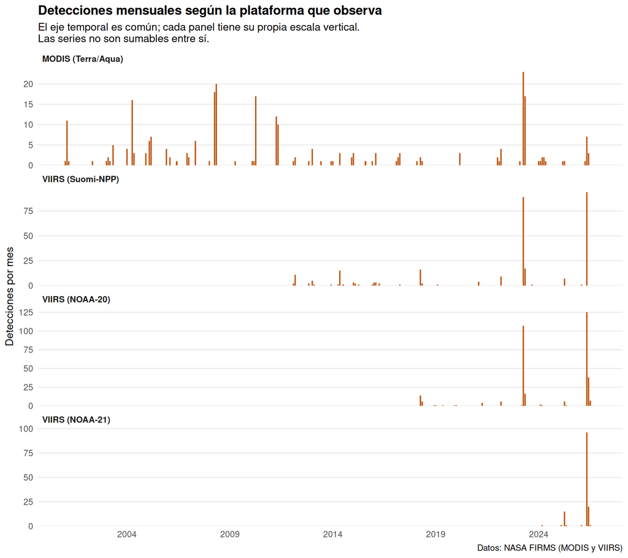

La escalera es evidente en la figura: cada panel arranca cuando su plataforma entró en servicio, y las alturas no son comparables entre paneles. Por eso hay cuatro reportes y no uno.

## Por qué importa tener varias

Mantener cuatro series paralelas no es redundancia. Sirve para tres cosas.

**Continuidad.** Las misiones Terra y Aqua, que llevan MODIS, terminan en 2027. La serie más larga del proyecto —veinticinco años— se corta ahí, y las plataformas VIIRS son su relevo. Tenerlas ya procesadas con la misma metodología permite que el empalme no se improvise.

**Contraste.** Cuando cuatro instrumentos independientes coinciden en un hallazgo, ese hallazgo no es un artefacto de ninguno de ellos. Y cuando difieren, la diferencia misma informa: el reporte de MODIS sostenía que buena parte de sus detecciones «en interior de bosque» eran un efecto de su footprint de más de un kilómetro invadiendo el bosque contiguo, y las plataformas VIIRS lo confirmaron al registrar mucho menos fuego de interior.

**Cobertura reciente.** Las series se sirven del procesamiento estándar y, a continuación, de los datos en tiempo casi real, que llegan hasta hace pocos días. Ese tramo final aparece marcado como provisional en todos los productos: sus detecciones se refinan cuando la NASA las reprocesa. NOAA-21 es un caso aparte: no tiene procesamiento estándar en absoluto, así que **todo** su registro es provisional.

## Lo que coinciden en mostrar

Cada reporte desarrolla sus propios resultados. Tres conclusiones aparecen en los cuatro, y por eso se enuncian aquí como rangos entre plataformas.

**Las quemas del «pastizal» ocurren en la marisma, no en potreros.** El mapa global de cobertura clasifica como pastizal buena parte del humedal estacional del parque. Cruzando cada detección con el Registro Nacional de Humedales del SINAC, entre el **93,6 y 97,5 %** de las detecciones dominadas por «pastizal» caen dentro de un humedal registrado, según la plataforma. El resultado se sostiene con footprints que van de un kilómetro a 375 metros, lo que descarta que sea un efecto de la superposición gruesa del píxel más grande.

**El fuego no bordea el bosque: lo rodea.** Sobre el mapa, las detecciones parecen dibujar el contorno del bloque forestal. Contrastadas contra un modelo nulo de puntos aleatorios, ocurren en terreno abierto entre el **58,6 y 79,9 %** de las veces, frente al 33,8 % que cabría esperar por azar; y la categoría de borde reúne entre el 18,6 y 27,9 %, frente al 28,2 % esperado, sin sobrerrepresentación en ninguna plataforma. El contorno es una ilusión geométrica: en un parque cuyo bosque forma un bloque compacto, cualquier concentración en terreno abierto traza su silueta.

**El fuego casi no entra al bosque.** El interior forestal reúne entre el **0,0 y 15,8 %** de las detecciones, contra un 38,0 % esperado por azar. El extremo inferior de ese rango corresponde a las plataformas VIIRS y el superior a MODIS, cuya diferencia se explica por el tamaño del footprint. El patrón es coherente con quemas en la marisma y el pastizal estacionalmente secos, que se detienen al llegar al bosque: el bosque seco cerrado retiene humedad y carece de combustible fino continuo.

**Limitación común.** El modelo nulo supone que cualquier punto del parque tiene la misma probabilidad de arder, lo que ignora la accesibilidad y la cercanía a caminos, linderos y cultivos. Descarta la explicación geométrica del patrón, pero no identifica la causa de las igniciones.

## Un episodio con cifra oficial: Catalina, mayo de 2026

El 28 de mayo de 2026 un rayo encendió el interior del humedal Catalina, en el sector estuarino del parque. Delfino.cr reportó, con cifras del Minae-Sinac, que el fuego afectó **cerca de 4 000 hectáreas** ([nota del 3 de junio de 2026](https://delfino.cr/2026/06/incendio-en-parque-nacional-palo-verde-afecto-cerca-de-4000-hectareas)); el combustible principal fue la *Typha*, una planta invasora que arde incluso sobre el agua. Es el único episodio del registro con fecha de ignición, causa y superficie conocidas por una fuente ajena al satélite, y por eso permite algo que ninguna otra parte de estos reportes permite: **auditar los productos contra una medición hecha en tierra**.

Las cuatro plataformas lo vieron, y la comparación entre ellas es en sí misma un resultado. Sobre el mismo fuego, los mismos días y el mismo humedal:

- **MODIS** — 10 detecciones en 3 días; FRP máximo 50,3 MW.
- **VIIRS S-NPP** — 94 detecciones en 3 días; FRP máximo 55,9 MW.
- **VIIRS NOAA-20** — 163 detecciones en 5 días; FRP máximo 68,1 MW.
- **VIIRS NOAA-21** — 116 detecciones en 3 días; FRP máximo 132,8 MW.

La diferencia no está en el fuego sino en el píxel: el de MODIS mide ~1 km de lado y promedia la radiancia sobre una superficie siete veces mayor que el de 375 m de VIIRS, de modo que un frente de llama que ocupa una fracción del píxel puede no elevar su temperatura aparente lo suficiente. **Un incendio de miles de hectáreas se reduce a un puñado de píxeles en la serie más larga**, que es el argumento más concreto a favor de mantener las cuatro plataformas en paralelo.

**Y el área quemada se queda muy corta.** Para mayo y junio de 2026 los productos de área quemada marcan entre 406 y 706 hectáreas dentro del parque, frente a las 4 000 reportadas oficialmente: **entre 5,7 y 9,8 veces menos superficie**.

La razón está en el algoritmo: declara quemado un píxel de 500 m cuando detecta un cambio persistente de reflectancia, y una quema de *Typha* sobre lámina de agua no lo produce —la vegetación emergente desaparece, el agua vuelve a dominar la señal y a las pocas semanas la superficie se parece a lo que era antes—. Las hectáreas de estos reportes **sirven para comparar años entre sí, no para responder cuántas hectáreas se quemaron**. Cada reporte desarrolla el episodio con sus propias cifras.

### Cómo avanzó: isócronas por pase

Separadas, cada plataforma VIIRS pasa dos veces al día; juntas, las tres observan el parque cada pocas horas. Entre el 29 de mayo a las 13:18 y el 2 de junio a la 01:16 (hora local) suman **16 pases** en 84 horas. Unir los footprints de fuego activo de cada pase a la envolvente de los anteriores produce un mapa de isócronas: **dónde llegó el fuego por primera vez y cuándo**. Es la única figura del proyecto que une plataformas, y lo hace solo para dibujar superficies: los conteos siguen sin sumarse, porque una detección vista por dos satélites casi simultáneos es la misma.

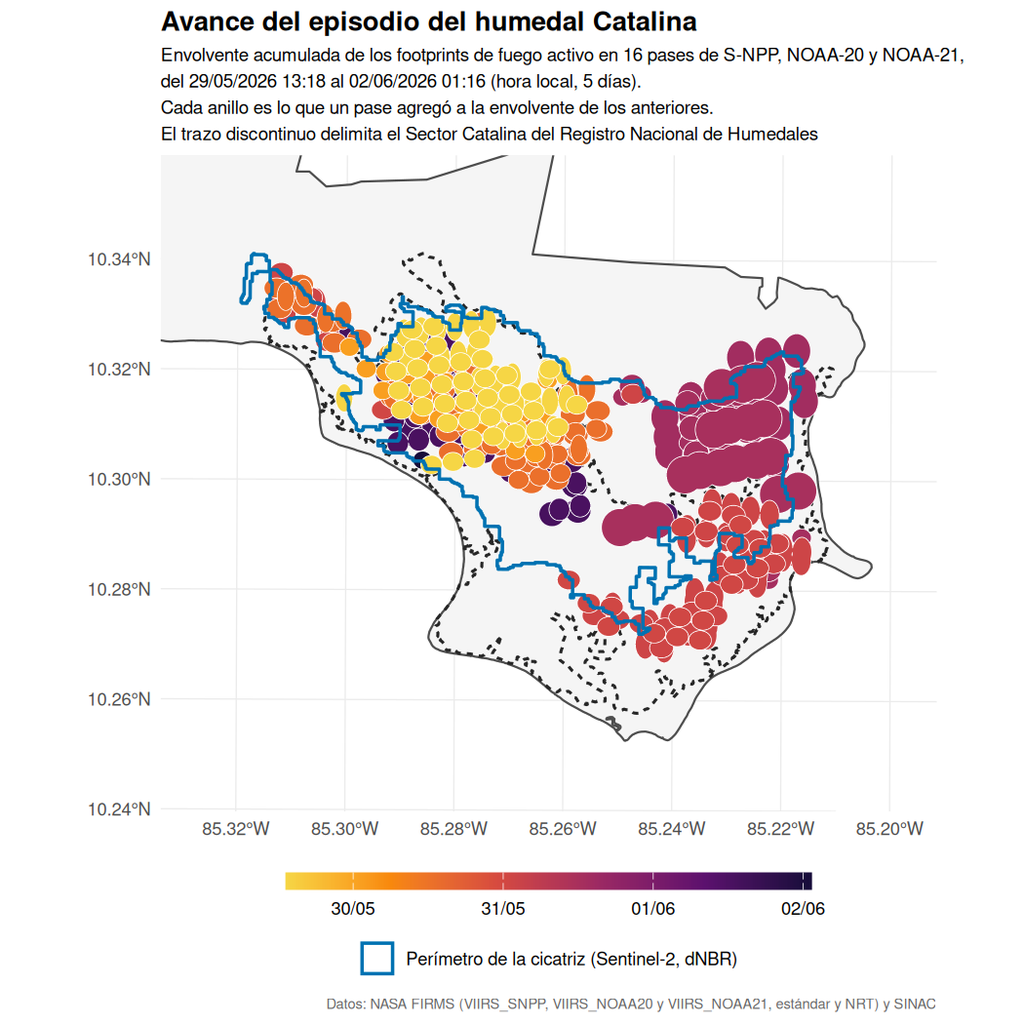

**No fue un frente único.** El primer día el fuego ocupó el centro-norte del sector; el 30 de mayo avanzó hacia el extremo noroeste; el 31 apareció en dos zonas nuevas y separadas entre sí, el este y el sur; y el 1 de junio volvió sobre el centro. Un typhal seco con lámina de agua debajo arde donde el combustible lo permite, no como un frente que se desplaza.

**El 31 de mayo fue el día decisivo.** De las 2 908 hectáreas de la envolvente final, 1 554 (el 53 %) se agregaron ese día en 7 pases. 5 de los 16 pases son nocturnos y aportaron 780 hectáreas: el fuego avanzó también de noche.

### La cicatriz, medida con Sentinel-2

Las tres mediciones anteriores salen de sensores de 375 m a 1 km. Sentinel-2 ve la cicatriz a 20 m: el dNBR entre una escena del 14 de mayo y otra del 11 de junio, ambas sin nubes sobre el parque, mide cuánta vegetación desapareció en cada píxel. El **perímetro** de la cicatriz no es un umbral suelto sino la mancha conexa anclada a la severidad moderada, con los islotes que el fuego rodeó incluidos, que es lo que un perímetro de incendio significa.

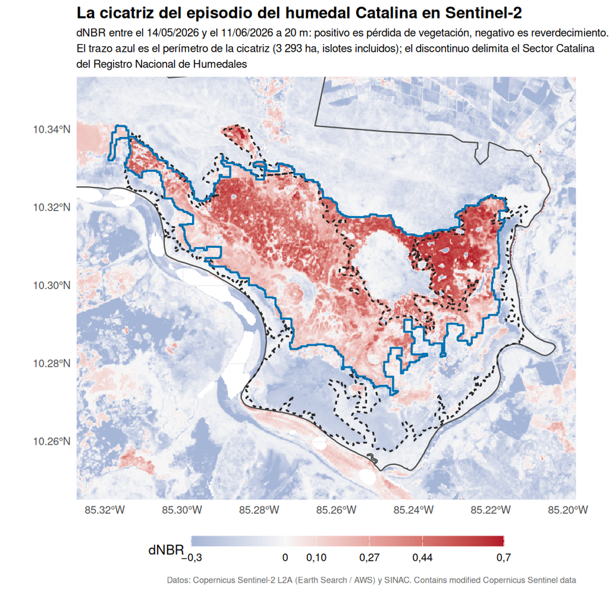

**3 293 hectáreas de perímetro**, de las cuales 2 407 muestran cambio y 886 son islotes sin quemar, casi todos bosque. Dentro, 1 371 hectáreas superan la severidad moderada y 702 la alta. El perímetro cubre el 59 % del Sector Catalina y se extiende 660 hectáreas fuera de él. La laguna de Palo Verde, el humedal vecino, tiene 657 hectáreas con cambio detectable pero solo 10 con severidad moderada: reverdeció con las primeras lluvias, no se quemó, y el perímetro apenas la toca (22 ha). Esa es la razón del anclaje: un umbral solo confunde reverdecimiento con quema.

**Fuego activo y cicatriz no coinciden del todo.** De las 2 908 hectáreas que alcanzó la envolvente de fuego activo, 2 145 caen dentro del perímetro y 763 fuera, sobre todo la franja del sur del 31 de mayo: hubo llama que el satélite vio pero no dejó cicatriz persistente a 20 m, lo esperable en un typhal sobre agua. A la inversa, 1 149 hectáreas del perímetro no tuvieron detección en ningún pase; 886 de ellas son los islotes sin quemar y el resto ardió entre pases.

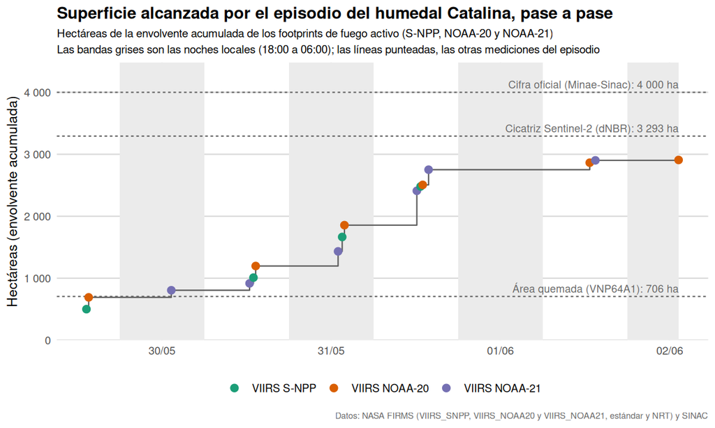

**Cuatro cifras que no se contradicen.** El área quemada de 500 m marca 706 hectáreas; la envolvente de fuego activo, 2 908; la cicatriz Sentinel-2, 3 293; la cifra oficial, 4 000. Miden cosas distintas. Las 702 hectáreas de severidad alta coinciden casi exactamente con las 706 del producto de área quemada: el producto de 500 m no falla al azar, **captura el núcleo severo y pierde el resto**. El perímetro de la cicatriz queda en el mismo orden que la cifra oficial, y la diferencia que resta cabe en lo que una cuadrilla cuenta como afectado y un satélite no ve cambiar. La brecha, entonces, está en el producto y no en el fuego, y las hectáreas de área quemada de estos reportes siguen sirviendo para comparar años entre sí, no para responder cuánto se quemó. El perímetro está en `outputs/maps/cicatriz_catalina_2026.gpkg` y sus cifras en `outputs/tables/cicatriz_catalina_2026.csv`.

### El episodio en video

Lo anterior, en movimiento. El reloj avanza media hora por cuadro, desde una hora antes del primer pase hasta el último: cada pase enciende sus detecciones y agrega su anillo a la envolvente, y los anillos se apagan con las horas, de amarillo a brasa. La noche oscurece el fondo, no el fuego; en la línea de tiempo, los pases nocturnos van en azul. Al cierre, con el reloj detenido en el último pase, aparecen el área quemada de 500 m, el perímetro de la cicatriz Sentinel-2 y la cifra oficial: las cuatro cifras en un solo cuadro.

[video not shown]

## Los reportes

- **MODIS (Terra/Aqua)** — 266 detecciones, de 01/2001 a 06/2026. Área quemada: MCD64A1.
- **VIIRS (Suomi-NPP)** — 296 detecciones, de 02/2012 a 05/2026. Área quemada: VNP64A1.
- **VIIRS (NOAA-20)** — 339 detecciones, de 04/2018 a 07/2026. Área quemada: VNP64A1, S-NPP.
- **VIIRS (NOAA-21)** — 136 detecciones, de 03/2024 a 07/2026. Área quemada: VNP64A1, S-NPP. Sin procesamiento estándar: datos provisionales.

Cada uno incluye mapa animado, video resumen, mapa interactivo con deslizador temporal, series y climatología, análisis de cobertura de la tierra y el contraste con el modelo nulo de paisaje.

## Fuentes de datos

- **NASA FIRMS** — Fire Information for Resource Management System. Detecciones de fuego activo de MODIS (Collection 6.1) y VIIRS (375 m) en sus versiones de procesamiento estándar y en tiempo casi real. https://firms.modaps.eosdis.nasa.gov/.
- **NASA LP DAAC** — productos mensuales de área quemada a 500 m: MCD64A1 v6.1 (MODIS) y VNP64A1 v002 (VIIRS/Suomi-NPP).
- **SINAC** — Sistema Nacional de Áreas de Conservación de Costa Rica: áreas silvestres protegidas, Registro Nacional de Humedales y Cobertura Forestal
  2023. https://geos1pne.sirefor.go.cr/wfs.
- **ESA WorldCover** — cobertura de la tierra 2021 a 10 m. https://esa-worldcover.org/.

El código de este proyecto está disponible en https://github.com/incendios-forestales/anomalias-termicas-paloverde.